# IODS course project

## Standardizing the data set

Standardize the dataset is standardized as follows:

```r
# center and standardize variables
boston_scaled <- scale(Boston)

# summaries of the scaled variables
summary(boston_scaled)
```

```
##       crim                 zn               indus              chas
##  Min.   :-0.419367   Min.   :-0.48724   Min.   :-1.5563   Min.   :-0.2723
##  1st Qu.:-0.410563   1st Qu.:-0.48724   1st Qu.:-0.8668   1st Qu.:-0.2723
##  Median :-0.390280   Median :-0.48724   Median :-0.2109   Median :-0.2723
##  Mean   : 0.000000   Mean   : 0.00000   Mean   : 0.0000   Mean   : 0.0000
##  3rd Qu.: 0.007389   3rd Qu.: 0.04872   3rd Qu.: 1.0150   3rd Qu.:-0.2723
##  Max.   : 9.924110   Max.   : 3.80047   Max.   : 2.4202   Max.   : 3.6648
##       nox                rm               age               dis
##  Min.   :-1.4644   Min.   :-3.8764   Min.   :-2.3331   Min.   :-1.2658
##  1st Qu.:-0.9121   1st Qu.:-0.5681   1st Qu.:-0.8366   1st Qu.:-0.8049
##  Median :-0.1441   Median :-0.1084   Median : 0.3171   Median :-0.2790
##  Mean   : 0.0000   Mean   : 0.0000   Mean   : 0.0000   Mean   : 0.0000
##  3rd Qu.: 0.5981   3rd Qu.: 0.4823   3rd Qu.: 0.9059   3rd Qu.: 0.6617
##  Max.   : 2.7296   Max.   : 3.5515   Max.   : 1.1164   Max.   : 3.9566
##       rad               tax             ptratio            black
##  Min.   :-0.9819   Min.   :-1.3127   Min.   :-2.7047   Min.   :-3.9033
##  1st Qu.:-0.6373   1st Qu.:-0.7668   1st Qu.:-0.4876   1st Qu.: 0.2049
##  Median :-0.5225   Median :-0.4642   Median : 0.2746   Median : 0.3808
##  Mean   : 0.0000   Mean   : 0.0000   Mean   : 0.0000   Mean   : 0.0000
##  3rd Qu.: 1.6596   3rd Qu.: 1.5294   3rd Qu.: 0.8058   3rd Qu.: 0.4332
##  Max.   : 1.6596   Max.   : 1.7964   Max.   : 1.6372   Max.   : 0.4406
##      lstat              medv
##  Min.   :-1.5296   Min.   :-1.9063
##  1st Qu.:-0.7986   1st Qu.:-0.5989
##  Median :-0.1811   Median :-0.1449
##  Mean   : 0.0000   Mean   : 0.0000
##  3rd Qu.: 0.6024   3rd Qu.: 0.2683
##  Max.   : 3.5453   Max.   : 2.9865
```

```r
# class of the boston_scaled object
class(boston_scaled)
```

```
## [1] "matrix" "array"
```

```r
# change the object to data frame
boston_scaled <- as.data.frame(boston_scaled)
```

## Categorize the data by crime rate

Then I’ll create a categorical variable `crim` (per capita crime rate by town) to be our factor variable and cut the variable by quantiles to get the high, low and middle rates of crime into their own categories. After this I’ll remove the original crim variable from the data set and substitute with a new one.

```r
# create a quantile vector of crim and print it
bins <- quantile(boston_scaled$crim)
bins
```

```
##           0%          25%          50%          75%         100%
## -0.419366929 -0.410563278 -0.390280295  0.007389247  9.924109610
```

```r
# create a categorical variable 'crime'
crime <- cut(boston_scaled$crim, breaks = bins, include.lowest = TRUE, labels = c("low", "med_low", "med_high", "high"))

# look at the table of the new factor crime
table(crime)
```

```
## crime
##      low  med_low med_high     high
##      127      126      126      127
```

```r
# remove original crim from the dataset
boston_scaled <- dplyr::select(boston_scaled, -crim)

# add the new categorical value to scaled data
boston_scaled <- data.frame(boston_scaled, crime)
```

Now, data will be divided to test and train sets, with 80 % of the data going to train set. We also save the correct classes from the test set and remove the crime variable from it.

```r
# number of rows in the Boston dataset
n <- nrow(boston_scaled)

# choose randomly 80% of the rows
ind <- sample(n,  size = n * 0.8)

# create train set
train <- boston_scaled[ind,]

# create test set
test <- boston_scaled[-ind,]

# save the correct classes from test data
correct_classes <- test$crime

# remove the crime variable from test data
test <- dplyr::select(test, -crime)
```

## linear discriminant analysis –> LDA (bi)plot

The categorical crime rate is used as the target variable in the linear discriminant analysis. All the other variables in the data set are used as predictor variables.

```r
# linear discriminant analysis
lda.fit <- lda(crime ~ ., data = train)

# print the lda.fit object
lda.fit
```

```
## Call:
## lda(crime ~ ., data = train)
##
## Prior probabilities of groups:
##      low  med_low med_high     high
## 0.240099 0.250000 0.250000 0.259901
##
## Group means:
##                  zn      indus         chas        nox         rm        age
## low       0.9582055 -0.9056934 -0.191151743 -0.8655342  0.4137765 -0.8331133
## med_low  -0.1081384 -0.2849558 -0.116404306 -0.5586551 -0.1852067 -0.3547142
## med_high -0.3751653  0.2250921  0.195445218  0.4269438  0.1519908  0.4300105
## high     -0.4872402  1.0170492 -0.009855719  1.0831635 -0.4187014  0.8415245
##                 dis        rad        tax     ptratio       black        lstat
## low       0.8423378 -0.6941624 -0.7317061 -0.37136602  0.37760154 -0.760531383
## med_low   0.4091449 -0.5395408 -0.4530513 -0.03616991  0.32051327 -0.091715276
## med_high -0.3929044 -0.4110490 -0.2946116 -0.34807037  0.07145412  0.008929827
## high     -0.8704539  1.6388211  1.5145512  0.78158339 -0.75667150  0.870096545
##                 medv
## low       0.49558157
## med_low  -0.05394879
## med_high  0.20398862
## high     -0.68069528
##
## Coefficients of linear discriminants:
##                 LD1         LD2         LD3
## zn       0.08683634  0.76933936 -1.08690740
## indus    0.06307990 -0.34723054  0.19928178
## chas    -0.06154639 -0.09275788  0.04591898
## nox      0.35361275 -0.70496725 -1.12035437
## rm      -0.08302342 -0.12733080 -0.17525953
## age      0.26339206 -0.27745620 -0.15392440
## dis     -0.04332242 -0.40747884  0.46521575
## rad      3.21826781  0.86728875 -0.08976814
## tax     -0.04188865  0.01917835  0.63192305
## ptratio  0.09487832  0.09666759 -0.26843225
## black   -0.11764121  0.03307842  0.14365454
## lstat    0.25156682 -0.27381872  0.38778576
## medv     0.17181605 -0.35946616 -0.15703831
##
## Proportion of trace:
##    LD1    LD2    LD3
## 0.9472 0.0373 0.0155
```

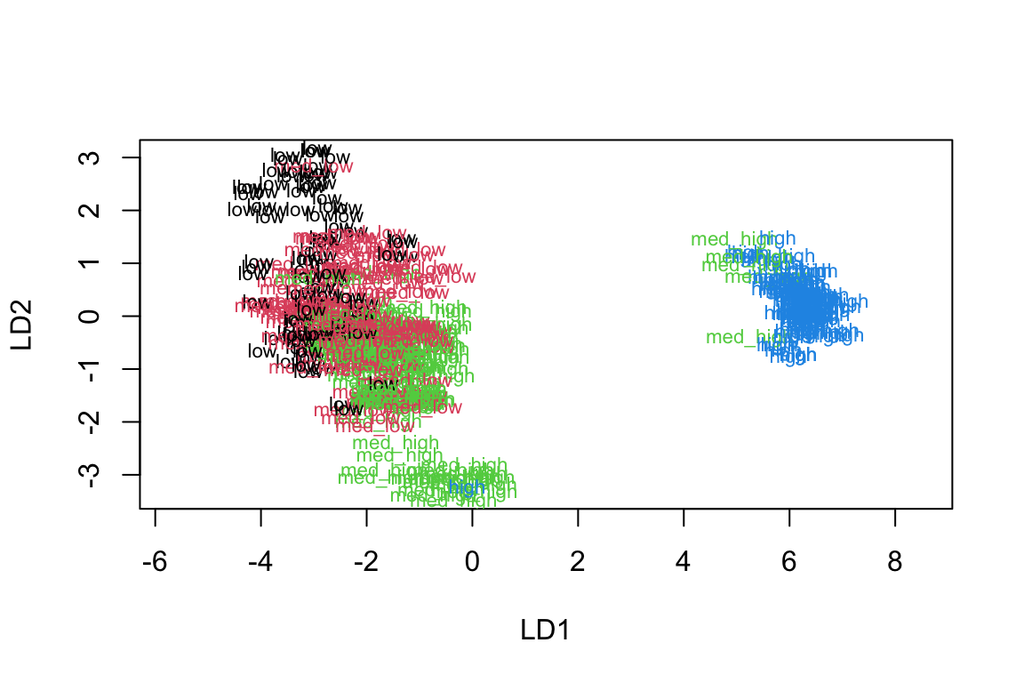

```r
# target classes as numeric
classes <- as.numeric(train$crime)

# plot the lda results
plot(lda.fit, dimen=2, col=classes)
```

Next I’d save the crime categories from the test set and remove the categorical crime variable from the test dataset. Then I’d predict the crime rate in the test set using the model from the train set and cross-tabulate it with the correct classes. However, I got error from this code and were not able to fix it in time.

Code to save the correct classes from test data: correct_classes <- test$crime

Code to remove the crime variable from test data: test <- dplyr::select(test, -crime)

Code to predict classes with test data: lda.pred <- predict(lda.fit, newdata = test)

Code to cross tabulate the results: table(correct = correct_classes, predicted = lda.pred$class)

## Reload Boston dataset

```r
data("Boston")
boston_scaled <- scale(Boston)
boston_euk_dist <- dist(boston_scaled)
```

Let’s run the k-means clustering with 3 clusters and visualise the result with few relevant variables.

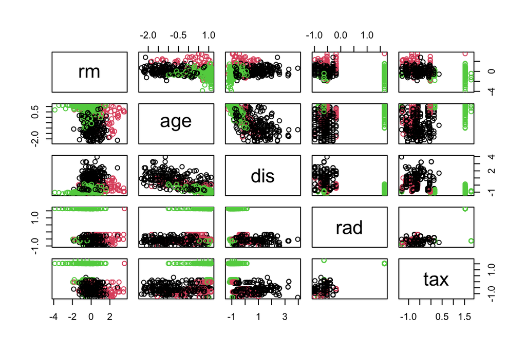

```r
# k-means clustering
km <-kmeans(boston_scaled, centers = 3)

# plot the Boston dataset with clusters
pairs(boston_scaled[,6:10], col = km$cluster)
```

Doesn’t look that good so let’s try 2 instead of 3

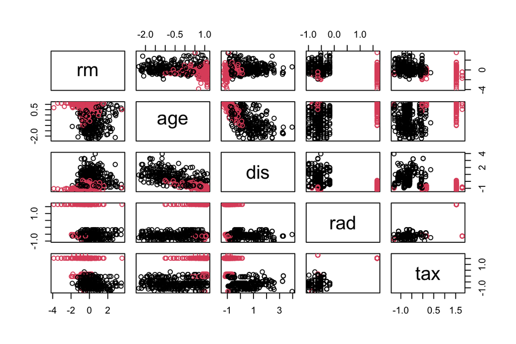

```r
# k-means clustering
km <-kmeans(boston_scaled, centers = 2)

# plot the Boston dataset with clusters
pairs(boston_scaled[,6:10], col = km$cluster)
```

# Assignment 5: Data Analysis excercise

```r
date()
```

```
## [1] "Mon Dec  4 23:27:07 2023"
```

## Reading data into R

```r
# Load required libraries
library(dplyr)
library(readr)
library(GGally)
# Specify the file path into CSV file
file_path <- "/Users/minmaunu/IODS-project/data/human.csv"

# Read the CSV file into a data frame
human <- read_csv(file_path)
# Explore the datasets

# See the structure of the data.
str(human)
```

```
## spc_tbl_ [148 × 9] (S3: spec_tbl_df/tbl_df/tbl/data.frame)
##  $ Country  : chr [1:148] "Norway" "Australia" "Switzerland" "Denmark" ...
##  $ Edu_Ratio: num [1:148] 1.007 0.997 0.983 0.989 0.969 ...
##  $ LF_Ratio : num [1:148] 0.891 0.819 0.825 0.884 0.829 ...
##  $ Edu.Exp  : num [1:148] 17.5 20.2 15.8 18.7 17.9 16.5 18.6 16.5 15.9 19.2 ...
##  $ Life.Exp : num [1:148] 81.6 82.4 83 80.2 81.6 80.9 80.9 79.1 82 81.8 ...
##  $ GNI      : num [1:148] 64992 42261 56431 44025 45435 ...
##  $ Mat.Mor  : num [1:148] 4 6 6 5 6 7 9 28 11 8 ...
##  $ Ado.Birth: num [1:148] 7.8 12.1 1.9 5.1 6.2 3.8 8.2 31 14.5 25.3 ...
##  $ Parli.F  : num [1:148] 39.6 30.5 28.5 38 36.9 36.9 19.9 19.4 28.2 31.4 ...
##  - attr(*, "spec")=
##   .. cols(
##   ..   Country = col_character(),
##   ..   Edu_Ratio = col_double(),
##   ..   LF_Ratio = col_double(),
##   ..   Edu.Exp = col_double(),
##   ..   Life.Exp = col_double(),
##   ..   GNI = col_double(),
##   ..   Mat.Mor = col_double(),
##   ..   Ado.Birth = col_double(),
##   ..   Parli.F = col_double()
##   .. )
##  - attr(*, "problems")=<externalptr>
```

```r
# See the dimension of the data.
dim(human)
```

```
## [1] 148   9
```

## Overview of the data

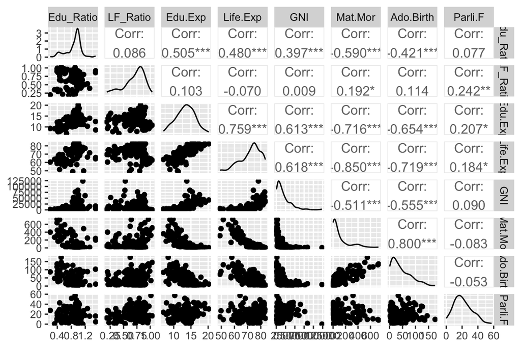

```r
# move the country names to rownames
library(tibble)
human_ <- column_to_rownames(human, "Country")

# Access GGally
library(GGally)

# visualize the 'human_' variables
ggpairs(human_, progress = FALSE)
```

```r
# Check the summary
summary(human_)
```

```
##    Edu_Ratio         LF_Ratio         Edu.Exp         Life.Exp
##  Min.   :0.1980   Min.   :0.1857   Min.   : 7.00   Min.   :49.00
##  1st Qu.:0.8097   1st Qu.:0.5971   1st Qu.:11.57   1st Qu.:68.38
##  Median :0.9444   Median :0.7504   Median :13.55   Median :74.35
##  Mean   :0.8766   Mean   :0.7006   Mean   :13.42   Mean   :72.44
##  3rd Qu.:0.9990   3rd Qu.:0.8385   3rd Qu.:15.32   3rd Qu.:77.45
##  Max.   :1.4967   Max.   :1.0380   Max.   :20.20   Max.   :83.50
##       GNI            Mat.Mor        Ado.Birth         Parli.F
##  Min.   :   680   Min.   :  1.0   Min.   :  0.60   Min.   : 0.00
##  1st Qu.:  5190   1st Qu.: 11.0   1st Qu.: 12.18   1st Qu.:12.15
##  Median : 12408   Median : 45.5   Median : 31.30   Median :19.50
##  Mean   : 18402   Mean   :120.9   Mean   : 43.72   Mean   :20.95
##  3rd Qu.: 25350   3rd Qu.:170.0   3rd Qu.: 69.05   3rd Qu.:27.82
##  Max.   :123124   Max.   :730.0   Max.   :175.60   Max.   :57.50
```

Most variables seem to be quite normally distributed, except GNI, maternal mortality and adolescent birth rate are skewed. There are many variables that correlate between each other, such as expected education and life expectancy have strong positive correlation, where as maternal mortality life expectancy have strong negative correlation.

## PCA on the non-standardized data

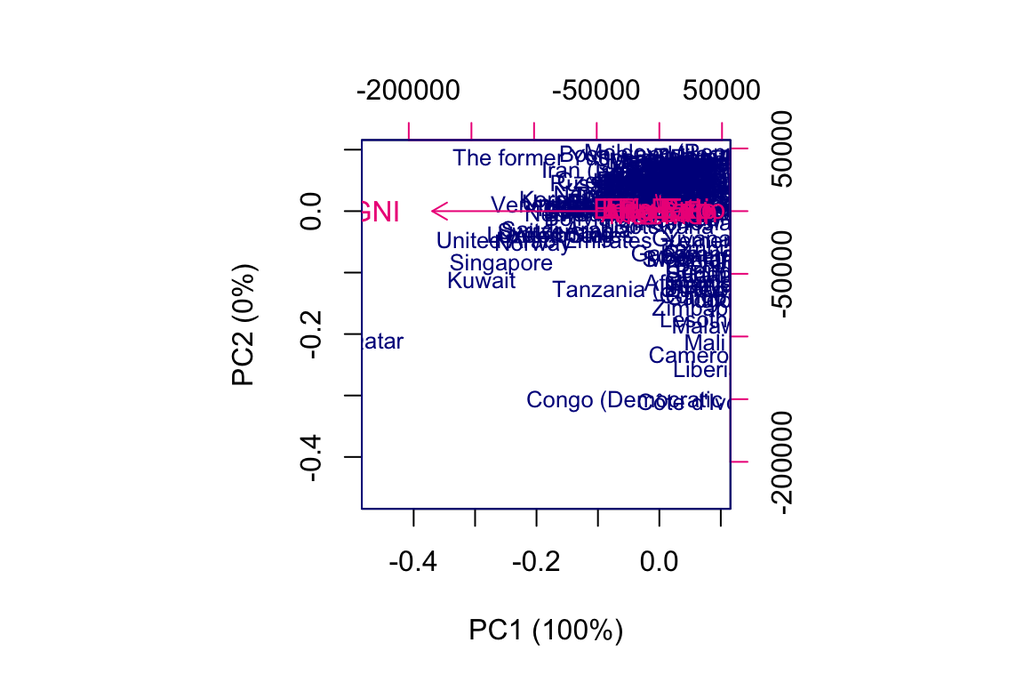

```r
# perform PCA
pca_human <- prcomp(human_)
s <-summary(pca_human)
pca_pr <- round(100*s$importance[2, ], digits = 1)
pc_lab <- paste0(names(pca_pr), " (", pca_pr, "%)")

# draw a biplot
biplot(pca_human, cex = c(0.8, 1), col = c("darkblue", "deeppink2"), xlab = pc_lab[1], ylab = pc_lab[2])
```

There is a large variation in GNI (thus GNI explains 100% of the variation), so we need to standardize the data.

## PCA on the standardized data

```r
# standardize the human data
human_scaled <- scale(human_)
pca_human <- prcomp(human_scaled)

#print out the summary
s <- summary(pca_human)

# rounded percentanges of variance captured by each PC
pca_pr <- round(100*s$importance[2, ], digits = 1)
pca_pr
```

```
##  PC1  PC2  PC3  PC4  PC5  PC6  PC7  PC8
## 51.7 16.3 10.0  7.9  6.2  3.8  2.9  1.2
```

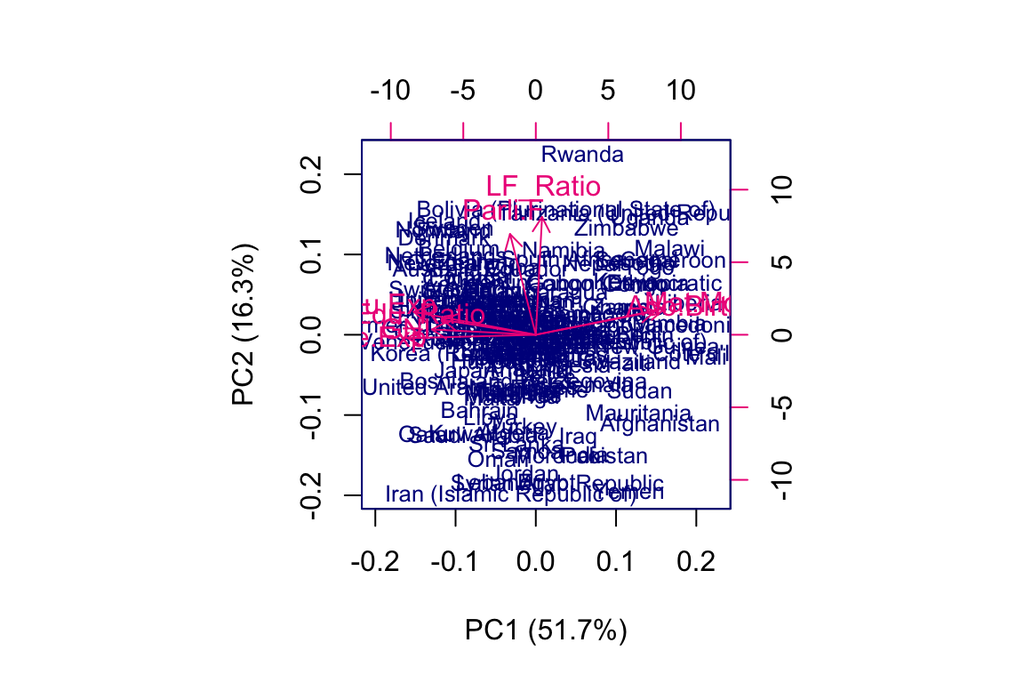

```r
# New PCA with standardized data
pc_lab <- paste0(names(pca_pr), " (", pca_pr, "%)")
biplot(pca_human, cex = c(0.8, 1), col = c("darkblue", "deeppink2"), xlab = pc_lab[1], ylab = pc_lab[2])
```

## Explore Tea Data Set

```r
# Load the data into R
tea <- read.csv("https://raw.githubusercontent.com/KimmoVehkalahti/Helsinki-Open-Data-Science/master/datasets/tea.csv", stringsAsFactors = TRUE)

# Load needed libraries
library(FactoMineR)
library(tidyr)
library(ggplot2)

# Explore the data set
str(tea)
```

```
## 'data.frame':    300 obs. of  36 variables:
##  $ breakfast       : Factor w/ 2 levels "breakfast","Not.breakfast": 1 1 2 2 1 2 1 2 1 1 ...
##  $ tea.time        : Factor w/ 2 levels "Not.tea time",..: 1 1 2 1 1 1 2 2 2 1 ...
##  $ evening         : Factor w/ 2 levels "evening","Not.evening": 2 2 1 2 1 2 2 1 2 1 ...
##  $ lunch           : Factor w/ 2 levels "lunch","Not.lunch": 2 2 2 2 2 2 2 2 2 2 ...
##  $ dinner          : Factor w/ 2 levels "dinner","Not.dinner": 2 2 1 1 2 1 2 2 2 2 ...
##  $ always          : Factor w/ 2 levels "always","Not.always": 2 2 2 2 1 2 2 2 2 2 ...
##  $ home            : Factor w/ 2 levels "home","Not.home": 1 1 1 1 1 1 1 1 1 1 ...
##  $ work            : Factor w/ 2 levels "Not.work","work": 1 1 2 1 1 1 1 1 1 1 ...
##  $ tearoom         : Factor w/ 2 levels "Not.tearoom",..: 1 1 1 1 1 1 1 1 1 2 ...
##  $ friends         : Factor w/ 2 levels "friends","Not.friends": 2 2 1 2 2 2 1 2 2 2 ...
##  $ resto           : Factor w/ 2 levels "Not.resto","resto": 1 1 2 1 1 1 1 1 1 1 ...
##  $ pub             : Factor w/ 2 levels "Not.pub","pub": 1 1 1 1 1 1 1 1 1 1 ...
##  $ Tea             : Factor w/ 3 levels "black","Earl Grey",..: 1 1 2 2 2 2 2 1 2 1 ...
##  $ How             : Factor w/ 4 levels "alone","lemon",..: 1 3 1 1 1 1 1 3 3 1 ...
```

[output cut: 22 more lines]

```r
dim(tea)
```

```
## [1] 300  36
```

```r
View(tea)
```

The Tea data set has 300 observations and 36 variables. It contains data from tea consumption and habits. Variable Age is integer while all others are factor variables.

[figure not shown]

```r
# Visualize the data set
gather(tea) %>% ggplot(aes(value)) + geom_bar() + facet_wrap("key", scales = "free") + theme(axis.text.x = element_text(angle = 45, hjust = 1, size = 7))
```

Unfortunately I don’t know why this figure looks like this. Not happy with it!

## Multiple Correspondence Analysis (MCA) with selected variables

```r
# column names to keep in the dataset
keep_columns <- c("Tea", "frequency", "sex", "work", "age_Q")

# select the 'keep_columns' to create a new dataset
tea_time <- dplyr::select(tea, keep_columns)
# look at the summaries and structure of the data
summary(tea_time)
```

```
##         Tea            frequency   sex           work       age_Q
##  black    : 74   +2/day     :127   F:178   Not.work:213   +60  :38
##  Earl Grey:193   1 to 2/week: 44   M:122   work    : 87   15-24:92
##  green    : 33   1/day      : 95                          25-34:69
##                  3 to 6/week: 34                          35-44:40
##                                                           45-59:61
```

```r
str(tea_time)
```

```
## 'data.frame':    300 obs. of  5 variables:
##  $ Tea      : Factor w/ 3 levels "black","Earl Grey",..: 1 1 2 2 2 2 2 1 2 1 ...
##  $ frequency: Factor w/ 4 levels "+2/day","1 to 2/week",..: 3 3 1 3 1 3 4 2 1 1 ...
##  $ sex      : Factor w/ 2 levels "F","M": 2 1 1 2 2 2 2 1 2 2 ...
##  $ work     : Factor w/ 2 levels "Not.work","work": 1 1 2 1 1 1 1 1 1 1 ...
##  $ age_Q    : Factor w/ 5 levels "+60","15-24",..: 4 5 5 2 5 2 4 4 4 4 ...
```

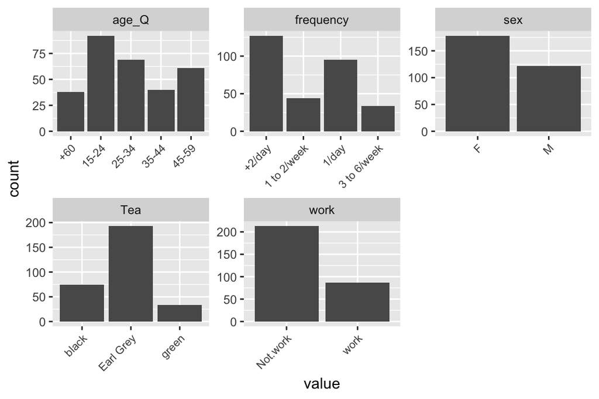

```r
# visualize the dataset
library(ggplot2)
pivot_longer(tea_time, cols = everything()) %>%
  ggplot(aes(value)) + facet_wrap("name", scales = "free") + geom_bar() + theme(axis.text.x = element_text(angle = 45, hjust = 1, size = 8))
```